# North Santiam Pedigree Project Analysis Notebook

```r
require(RLDNe)
require(DHARMa)
require(MASS)
require(lme4)
require(kableExtra)
require(gt)
require(gtsummary)
require(tidyverse)
require(magrittr)
```

# Summary

This notebook contains a log of all analyses for the 2022 North Santiam Chinook salmon genetic pedigree study. Inference of the pedigree used here is conducted in a separate notebook titled “parentage_assignment_log” in this same repository.

**Goals**  
(1) Summarise assignments  
(2) Estimate total lifetime fitness (TLF) for parent cohorts  
(3) Estimate cohort replacement rates for parent cohorts  
(4) Assess variables that influence fitness with general linear models  
(5) Estimate effective number of breeders using NeEstimator

This is an R notebook. The .html version of this file is a fully rendered and interactive log. To view it, save the html and open in a browse. The .rmd version can be opened within R studio. To reproduce results or edit the analysis: clone the full repository onto tyour local machine and open the r project in rstudio. This will provide all needed data and objects.

# Data

## Import

Here we import metadata and the final pedigree.

```r
load("../parentage/parentage_results/meta_data.R")
load("../parentage/parentage_results/pedigree.R")

# let's get the metadata on the pedigree
pedigree_meta <- meta_data %>%
  select(sample_id, year, type, date) %>%
  rename_with(.fn = ~ paste0("offspring_", .x)) %>%
  right_join(pedigree, by = c("offspring_sample_id" = "offspring_sample_id"))

#father
pedigree_meta <- meta_data %>%
  select(sample_id, year, type, date, above_below) %>%
  rename_with(.fn = ~ paste0("father_", .x)) %>%
  right_join(pedigree_meta, by = c("father_sample_id" = "father")) %>%
  rename(father = father_sample_id)

#mother
pedigree_meta <- meta_data %>%
  select(sample_id, year, type, date, above_below) %>%
  rename_with(.fn = ~ paste0("mother_", .x)) %>%
  right_join(pedigree_meta, by = c("mother_sample_id" = "mother")) %>%
  rename(mother = mother_sample_id)
```

## Dataset Summary

Here we summarize the metadata of salmon that are part of the final filtered dataset used as candidate parents and offspring.

```r
tbl_summary(select(meta_data, type, year), by = type, percent = "row") %>%
  modify_header(label ~ "") %>%
  modify_spanning_header(c("stat_1", "stat_2", "stat_3", "stat_4", "stat_5") ~ "**type**") %>%
  as_kable_extra() %>%
  kable_classic(full_width = F, html_font = "Cambria")# %>%
```

|  | type carcass, N = 427 | type carcass_above, N = 15 | type outplant, N = 6,349 | type reintro, N = 5,135 | type reintro_above, N = 431 |
| --- | --- | --- | --- | --- | --- |
| year |  |  |  |  |  |
| 2011 | 197 (57%) | 0 (0%) | 149 (43%) | 0 (0%) | 0 (0%) |
| 2012 | 84 (25%) | 0 (0%) | 258 (75%) | 0 (0%) | 0 (0%) |
| 2013 | 39 (2.3%) | 0 (0%) | 1,125 (65%) | 554 (32%) | 0 (0%) |
| 2014 | 46 (2.8%) | 0 (0%) | 861 (52%) | 754 (45%) | 0 (0%) |
| 2015 | 19 (1.1%) | 15 (0.9%) | 1,042 (63%) | 148 (8.9%) | 431 (26%) |
| 2016 | 19 (1.0%) | 0 (0%) | 1,310 (71%) | 520 (28%) | 0 (0%) |
| 2017 | 14 (0.7%) | 0 (0%) | 1,604 (76%) | 505 (24%) | 0 (0%) |
| 2018 | 3 (1.2%) | 0 (0%) | 0 (0%) | 248 (99%) | 0 (0%) |
| 2019 | 6 (0.7%) | 0 (0%) | 0 (0%) | 813 (99%) | 0 (0%) |
| 2020 | 0 (0%) | 0 (0%) | 0 (0%) | 1,593 (100%) | 0 (0%) |

<sup>1</sup> n (%)

The dataset described above includes all **sampled** parents from 2011 - 2017 and all **sampled** offspring from 2014 - 2020, after filtering for missingness and duplicates.

Note: Some of the results we work with in this report are properties of parents, and others are properties of offspring. Throughout the report we include results for parent years 2011-2015, and offspring years for 2016-2020. The pedigree is complete (full age structure present in dataset) for parent years 2011-2015 and for offspring years 2016-2020.  
For example: Fitness is a property of parents and we report fitness for parent years 2011-2015, so it requires information from additional offspring years that are not part of the range of years for which we report offspring level data (2014 and 2015).  
As another example, while 2014 offspring are included in the pedigree, the complete set of their potential parents are not (2009, 2010). This is because we do not include results for parents years 2009 or 2010, but we do include 2011. Similarly 2017 parents are included in the study because they contribute as parents to 2020 offspring year, but we do not sample their potential age 4 and age 5 offspring, so we do not report full 2017 parent level results.

### Releases

Let’s summarise outplant release locations by location and date to present in table 2. Only present 2016 and 2017 because table 2 already complete for 2011 - 2015

```r
kable(meta_data %>%
  filter(above_below == "above") %>%
    filter(year > 2015) %>%
  count(year, date, location), align = "c", caption = "Table 2 from draft report totals") %>%
  kable_classic(full_width = F, html_font = "Cambria")
```

Table 2 from draft report totals

| year | date | location | n |
| --- | --- | --- | --- |
| 2016 | NA | breitenbush river | 1253 |
| 2016 | NA | horn creek | 57 |
| 2017 | 2017-06-27 | log deck | 175 |
| 2017 | 2017-07-06 | breitenbush river | 167 |
| 2017 | 2017-07-10 | log deck | 155 |
| 2017 | 2017-07-13 | breitenbush river | 1 |
| 2017 | 2017-07-13 | horn creek | 65 |
| 2017 | 2017-07-17 | log deck | 153 |
| 2017 | 2017-07-26 | log deck | 142 |
| 2017 | 2017-08-08 | breitenbush river | 76 |
| 2017 | 2017-08-14 | log deck | 57 |
| 2017 | 2017-08-22 | breitenbush river | 68 |
| 2017 | 2017-08-31 | log deck | 165 |
| 2017 | 2017-09-13 | log deck | 103 |
| 2017 | 2017-09-18 | breitenbush river | 277 |

```r
kable(meta_data %>%
  filter(above_below == "above", geno_sex == "F") %>%
    filter(year > 2015) %>%
  count(year, date, location), align = "c", caption = "Table 2 from draft report females") %>%
  kable_classic(full_width = F, html_font = "Cambria")
```

Table 2 from draft report females

| year | date | location | n |
| --- | --- | --- | --- |
| 2016 | NA | breitenbush river | 830 |
| 2016 | NA | horn creek | 28 |
| 2017 | 2017-06-27 | log deck | 89 |
| 2017 | 2017-07-06 | breitenbush river | 59 |
| 2017 | 2017-07-10 | log deck | 66 |
| 2017 | 2017-07-13 | horn creek | 30 |
| 2017 | 2017-07-17 | log deck | 71 |
| 2017 | 2017-07-26 | log deck | 74 |
| 2017 | 2017-08-08 | breitenbush river | 26 |
| 2017 | 2017-08-14 | log deck | 25 |
| 2017 | 2017-08-22 | breitenbush river | 24 |
| 2017 | 2017-08-31 | log deck | 72 |
| 2017 | 2017-09-13 | log deck | 23 |
| 2017 | 2017-09-18 | breitenbush river | 132 |

```r
kable(meta_data %>%
  filter(above_below == "above", geno_sex == "M") %>%
    filter(year > 2015) %>%
  count(year, date, location), align = "c", caption = "Table 2 from draft report males") %>%
  kable_classic(full_width = F, html_font = "Cambria")
```

Table 2 from draft report males

| year | date | location | n |
| --- | --- | --- | --- |
| 2016 | NA | breitenbush river | 423 |
| 2016 | NA | horn creek | 29 |
| 2017 | 2017-06-27 | log deck | 86 |
| 2017 | 2017-07-06 | breitenbush river | 108 |
| 2017 | 2017-07-10 | log deck | 89 |
| 2017 | 2017-07-13 | breitenbush river | 1 |
| 2017 | 2017-07-13 | horn creek | 35 |
| 2017 | 2017-07-17 | log deck | 82 |
| 2017 | 2017-07-26 | log deck | 68 |
| 2017 | 2017-08-08 | breitenbush river | 50 |
| 2017 | 2017-08-14 | log deck | 32 |
| 2017 | 2017-08-22 | breitenbush river | 44 |
| 2017 | 2017-08-31 | log deck | 93 |
| 2017 | 2017-09-13 | log deck | 80 |
| 2017 | 2017-09-18 | breitenbush river | 145 |

# Assignment Rates

This section calculates number of assignments between different parent and offspring classes.

## Table 3

Here we present the assignment rates into the format of table 3 from the draft report

Each table in the notebook below can be used to recreate table 3. Each table represents a single pair of offspring and parent years. The type of offspring is listed in the first column and the results are split between parent types along the remaining columns (e.g. same format as table 3)

When the “type” of parent varies between two parents, the female parent type is listed first. This is slightly different from table 3, so close attention is required when doing data entry here. For example, if an offspring is assigned to a reintroduced mother and carcass father, the column would be called “reintro/carcass.”

```r
# the format of the table is difficult to produce in r
# let's not change the format of the table, instead we'll write some helper functions for filling it out

#let's add a column for the type of assignment, and one for combined types
pedigree_meta %<>%
  mutate(assn_type = case_when((mother == "none" & father == "none") ~ "none",
                               (mother == "none" & father != "none") ~ "male_only",
                               (mother != "none" & father == "none") ~ "female_only",
                               (mother != "none" & father != "none") ~ "pair",)) %>%
  mutate(parent_type = case_when((father_type == mother_type) ~ father_type,
                                 (is.na(father_type) & !(is.na(mother_type))) ~ mother_type,
                                  (is.na(mother_type) & !(is.na(father_type))) ~ father_type,
                                   (father_type != mother_type) ~ paste(mother_type, father_type, sep = "/")))

# function
t4_helper <- function(p_year, off_year){pedigree_meta %>%
  filter(offspring_year == off_year) %>%
  mutate(parent_year = (coalesce(father_year, mother_year))) %>%
  filter(parent_year == p_year) %>%
  mutate(parent_type = as.factor(parent_type)) %>%
  select(offspring_type, parent_type, assn_type) %>%
  tbl_strata(
    strata = parent_type,
    .tbl_fun = ~ .x %>%
      tbl_summary( by = assn_type, percent = NULL)
  ) %>%
  modify_caption(paste(paste("parent year: ", p_year), paste("offspring year: ", off_year), sep = "  ,")) %>%
  as_kable_extra() %>%
  kable_classic(full_width = F, html_font = "Cambria")
}
```

### Offspring Year 2016

```r
#t4 helper function example
t4_helper("2011", "2016")
```

parent year: 2011 ,offspring year: 2016

| Characteristic | carcass female_only, N = 4 | carcass pair, N = 1 | outplant female_only, N = 7 | outplant male_only, N = 4 | outplant pair, N = 32 |
| --- | --- | --- | --- | --- | --- |
| offspring_type |  |  |  |  |  |
| carcass | 1 (25%) | 0 (0%) |  |  |  |
| reintro | 3 (75%) | 1 (100%) | 7 (100%) | 4 (100%) | 32 (100%) |

<sup>1</sup> n (%)

```r
t4_helper("2012", "2016")
```

parent year: 2012 ,offspring year: 2016

| Characteristic | carcass female_only, N = 7 | carcass male_only, N = 7 | outplant female_only, N = 14 | outplant male_only, N = 3 | outplant pair, N = 69 |
| --- | --- | --- | --- | --- | --- |
| offspring_type |  |  |  |  |  |
| carcass | 1 (14%) | 1 (14%) |  |  |  |
| reintro | 6 (86%) | 6 (86%) | 14 (100%) | 3 (100%) | 69 (100%) |

<sup>1</sup> n (%)

```r
t4_helper("2013", "2016")
```

parent year: 2013 ,offspring year: 2016

| Characteristic | carcass female_only, N = 1 | carcass male_only, N = 1 | outplant female_only, N = 7 | outplant male_only, N = 12 | outplant pair, N = 5 | reintro female_only, N = 8 | reintro male_only, N = 6 | reintro pair, N = 3 |
| --- | --- | --- | --- | --- | --- | --- | --- | --- |
| offspring_type |  |  |  |  |  |  |  |  |
| carcass | 1 (100%) | 0 (0%) | 0 (0%) | 1 (8.3%) | 0 (0%) | 0 (0%) | 1 (17%) | 0 (0%) |
| reintro | 0 (0%) | 1 (100%) | 7 (100%) | 11 (92%) | 5 (100%) | 8 (100%) | 5 (83%) | 3 (100%) |

<sup>1</sup> n (%)

### Offspring Year 2017

```r
t4_helper("2012", "2017")
```

parent year: 2012 ,offspring year: 2017

| Characteristic | carcass female_only, N = 2 | carcass male_only, N = 4 | carcass pair, N = 1 | outplant female_only, N = 10 | outplant male_only, N = 2 | outplant pair, N = 66 |
| --- | --- | --- | --- | --- | --- | --- |
| offspring_type |  |  |  |  |  |  |
| reintro | 2 (100%) | 4 (100%) | 1 (100%) | 10 (100%) | 1 (50%) | 66 (100%) |
| carcass |  |  |  | 0 (0%) | 1 (50%) | 0 (0%) |

<sup>1</sup> n (%)

```r
t4_helper("2013", "2017")
```

parent year: 2013 ,offspring year: 2017

| Characteristic | carcass/reintro pair, N = 1 | outplant female_only, N = 11 | outplant male_only, N = 13 | outplant pair, N = 148 | reintro female_only, N = 7 | reintro male_only, N = 17 | reintro pair, N = 37 |
| --- | --- | --- | --- | --- | --- | --- | --- |
| offspring_type |  |  |  |  |  |  |  |
| reintro | 1 (100%) | 11 (100%) | 12 (92%) | 147 (99%) | 7 (100%) | 16 (94%) | 37 (100%) |
| carcass |  | 0 (0%) | 1 (7.7%) | 1 (0.7%) | 0 (0%) | 1 (5.9%) | 0 (0%) |

<sup>1</sup> n (%)

```r
t4_helper("2014", "2017")
```

parent year: 2014 ,offspring year: 2017

| Characteristic | carcass female_only, N = 1 | carcass male_only, N = 1 | outplant female_only, N = 3 | outplant male_only, N = 2 | outplant pair, N = 2 | reintro female_only, N = 3 | reintro male_only, N = 4 | reintro pair, N = 8 |
| --- | --- | --- | --- | --- | --- | --- | --- | --- |
| offspring_type |  |  |  |  |  |  |  |  |
| reintro | 1 (100%) | 1 (100%) | 3 (100%) | 2 (100%) | 2 (100%) | 3 (100%) | 3 (75%) | 8 (100%) |
| carcass |  |  |  |  |  | 0 (0%) | 1 (25%) | 0 (0%) |

<sup>1</sup> n (%)

### Offspring Year 2018

```r
t4_helper("2013", "2018")
```

parent year: 2013 ,offspring year: 2018

| Characteristic | outplant female_only, N = 2 | outplant male_only, N = 2 | outplant pair, N = 42 | reintro female_only, N = 2 | reintro male_only, N = 2 | reintro pair, N = 8 |
| --- | --- | --- | --- | --- | --- | --- |
| offspring_type |  |  |  |  |  |  |
| reintro | 2 (100%) | 2 (100%) | 42 (100%) | 2 (100%) | 2 (100%) | 8 (100%) |

<sup>1</sup> n (%)

```r
t4_helper("2014", "2018")
```

parent year: 2014 ,offspring year: 2018

| Characteristic | outplant female_only, N = 2 | outplant male_only, N = 4 | outplant pair, N = 38 | reintro female_only, N = 8 | reintro male_only, N = 6 | reintro pair, N = 11 |
| --- | --- | --- | --- | --- | --- | --- |
| offspring_type |  |  |  |  |  |  |
| carcass | 0 (0%) | 1 (25%) | 0 (0%) |  |  |  |
| reintro | 2 (100%) | 3 (75%) | 38 (100%) | 8 (100%) | 6 (100%) | 11 (100%) |

<sup>1</sup> n (%)

```r
t4_helper("2015", "2018")
```

parent year: 2015 ,offspring year: 2018

| Characteristic | carcass male_only, N = 1 | outplant female_only, N = 3 | outplant male_only, N = 4 | outplant pair, N = 9 | outplant/reintro_above pair, N = 3 | reintro female_only, N = 3 | reintro male_only, N = 5 | reintro pair, N = 14 | reintro_above female_only, N = 6 | reintro_above male_only, N = 2 | reintro_above pair, N = 2 | reintro_above/outplant pair, N = 1 |
| --- | --- | --- | --- | --- | --- | --- | --- | --- | --- | --- | --- | --- |
| offspring_type |  |  |  |  |  |  |  |  |  |  |  |  |
| carcass | 1 (100%) |  |  |  |  |  |  |  |  |  |  |  |
| reintro |  | 3 (100%) | 4 (100%) | 9 (100%) | 3 (100%) | 3 (100%) | 5 (100%) | 14 (100%) | 6 (100%) | 2 (100%) | 2 (100%) | 1 (100%) |

<sup>1</sup> n (%)

### Offspring Year 2019

```r
t4_helper("2014", "2019")
```

parent year: 2014 ,offspring year: 2019

| Characteristic | outplant female_only, N = 2 | outplant male_only, N = 10 | outplant pair, N = 24 | reintro female_only, N = 3 | reintro male_only, N = 4 | reintro pair, N = 3 |
| --- | --- | --- | --- | --- | --- | --- |
| offspring_type |  |  |  |  |  |  |
| reintro | 2 (100%) | 10 (100%) | 24 (100%) | 3 (100%) | 4 (100%) | 3 (100%) |

<sup>1</sup> n (%)

```r
t4_helper("2015", "2019")
```

parent year: 2015 ,offspring year: 2019

| Characteristic | carcass female_only, N = 1 | carcass_above male_only, N = 2 | carcass_above/outplant pair, N = 1 | outplant female_only, N = 29 | outplant male_only, N = 21 | outplant pair, N = 157 | outplant/reintro_above pair, N = 102 | reintro female_only, N = 19 | reintro male_only, N = 10 | reintro pair, N = 26 | reintro_above female_only, N = 26 | reintro_above male_only, N = 30 | reintro_above pair, N = 90 | reintro_above/carcass_above pair, N = 1 | reintro_above/outplant pair, N = 17 | reintro/carcass pair, N = 1 |
| --- | --- | --- | --- | --- | --- | --- | --- | --- | --- | --- | --- | --- | --- | --- | --- | --- |
| offspring_type |  |  |  |  |  |  |  |  |  |  |  |  |  |  |  |  |
| reintro | 1 (100%) | 2 (100%) | 1 (100%) | 28 (97%) | 20 (95%) | 157 (100%) | 102 (100%) | 18 (95%) | 10 (100%) | 26 (100%) | 26 (100%) | 30 (100%) | 90 (100%) | 1 (100%) | 17 (100%) | 1 (100%) |
| carcass |  |  |  | 1 (3.4%) | 1 (4.8%) | 0 (0%) |  | 1 (5.3%) | 0 (0%) | 0 (0%) |  |  |  |  |  |  |

<sup>1</sup> n (%)

```r
t4_helper("2016", "2019")
```

parent year: 2016 ,offspring year: 2019

| Characteristic | carcass male_only, N = 1 | outplant female_only, N = 7 | outplant male_only, N = 10 | outplant pair, N = 56 | reintro female_only, N = 4 | reintro male_only, N = 3 | reintro pair, N = 5 |
| --- | --- | --- | --- | --- | --- | --- | --- |
| offspring_type |  |  |  |  |  |  |  |
| reintro | 1 (100%) | 7 (100%) | 10 (100%) | 56 (100%) | 4 (100%) | 3 (100%) | 5 (100%) |

<sup>1</sup> n (%)

### Offspring Year 2020

```r
t4_helper("2015", "2020")
```

parent year: 2015 ,offspring year: 2020

| Characteristic | outplant female_only, N = 21 | outplant male_only, N = 19 | outplant pair, N = 55 | outplant/reintro_above pair, N = 48 | reintro female_only, N = 1 | reintro male_only, N = 3 | reintro pair, N = 1 | reintro_above female_only, N = 13 | reintro_above male_only, N = 11 | reintro_above pair, N = 34 | reintro_above/carcass_above pair, N = 2 | reintro_above/outplant pair, N = 8 |
| --- | --- | --- | --- | --- | --- | --- | --- | --- | --- | --- | --- | --- |
| offspring_type |  |  |  |  |  |  |  |  |  |  |  |  |
| reintro | 21 (100%) | 19 (100%) | 55 (100%) | 48 (100%) | 1 (100%) | 3 (100%) | 1 (100%) | 13 (100%) | 11 (100%) | 34 (100%) | 2 (100%) | 8 (100%) |

<sup>1</sup> n (%)

```r
t4_helper("2016", "2020")
```

parent year: 2016 ,offspring year: 2020

| Characteristic | carcass female_only, N = 3 | carcass male_only, N = 1 | outplant female_only, N = 76 | outplant male_only, N = 44 | outplant pair, N = 981 | reintro female_only, N = 22 | reintro male_only, N = 17 | reintro pair, N = 67 |
| --- | --- | --- | --- | --- | --- | --- | --- | --- |
| offspring_type |  |  |  |  |  |  |  |  |
| reintro | 3 (100%) | 1 (100%) | 76 (100%) | 44 (100%) | 981 (100%) | 22 (100%) | 17 (100%) | 67 (100%) |

<sup>1</sup> n (%)

```r
t4_helper("2017", "2020")
```

parent year: 2017 ,offspring year: 2020

| Characteristic | outplant female_only, N = 1 | outplant male_only, N = 1 | outplant pair, N = 7 | reintro female_only, N = 3 | reintro male_only, N = 3 | reintro pair, N = 7 |
| --- | --- | --- | --- | --- | --- | --- |
| offspring_type |  |  |  |  |  |  |
| reintro | 1 (100%) | 1 (100%) | 7 (100%) | 3 (100%) | 3 (100%) | 7 (100%) |

<sup>1</sup> n (%)

## Age at Maturity

We can also calculate age at maturity for offspring year using these data. These results appear in the draft report in the text, but we will summarise here in a table and a figure

```r
# report text is formatted as number and percent per age for each offspring year

kable(pedigree_meta %>%
        filter(!(offspring_year %in% c("2014", "2015"))) %>%
  mutate(parent_year = (coalesce(father_year, mother_year))) %>%
  filter(!(is.na(parent_year))) %>%
  mutate(age = as.numeric(offspring_year) - as.numeric(parent_year)) %>%
  group_by(offspring_year, age) %>%
  summarise(n = n()) %>%
  mutate(percent = 100*(n/sum(n))), digits = 0) %>%
  kable_classic(full_width = F, html_font = "Cambria") %>%
  kable_styling(fixed_thead = T) %>%
  collapse_rows(columns = 1)
```

| offspring_year | age | n | percent |
| --- | --- | --- | --- |
| 2016 | 3 | 43 | 23 |
| 2016 | 4 | 100 | 52 |
| 2016 | 5 | 48 | 25 |
| 2017 | 3 | 24 | 7 |
| 2017 | 4 | 234 | 68 |
| 2017 | 5 | 85 | 25 |
| 2018 | 3 | 53 | 29 |
| 2018 | 4 | 69 | 38 |
| 2018 | 5 | 58 | 32 |
| 2019 | 3 | 86 | 13 |
| 2019 | 4 | 533 | 80 |
| 2019 | 5 | 46 | 7 |
| 2020 | 3 | 22 | 2 |
| 2020 | 4 | 1211 | 84 |
| 2020 | 5 | 216 | 15 |

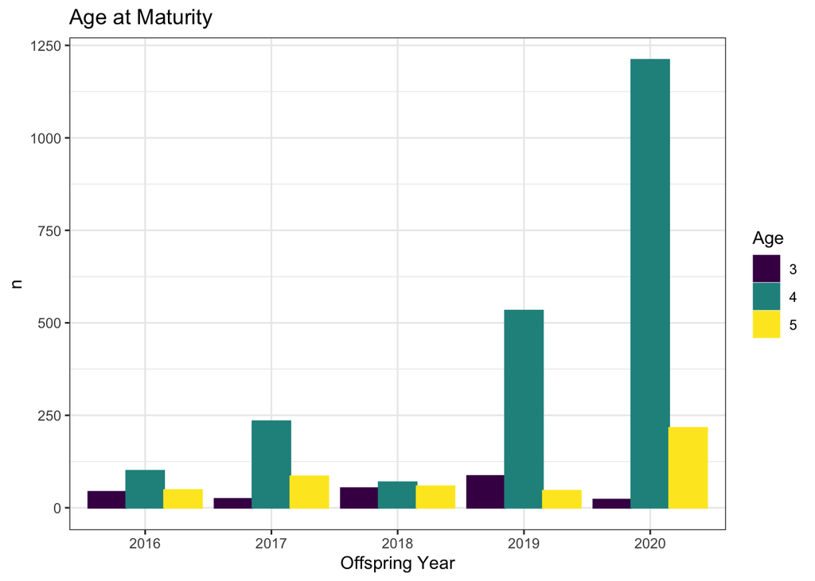

```r
aam_data <- pedigree_meta %>%
        filter(!(offspring_year %in% c("2014", "2015"))) %>%
  mutate(parent_year = (coalesce(father_year, mother_year))) %>%
  filter(!(is.na(parent_year))) %>%
  mutate(age = as.numeric(offspring_year) - as.numeric(parent_year)) %>%
  group_by(offspring_year, age) %>%
  summarise(n = n()) %>%
  mutate(percent = 100*(n/sum(n)))

ggplot(data = aam_data)+geom_bar(aes(x = offspring_year, color = as.factor(age), fill = as.factor(age), y = n), stat = "identity", position = "dodge")+scale_fill_viridis_d(name = "Age")+scale_colour_viridis_d(name = "Age")+theme_bw()+xlab("Offspring Year")+ggtitle("Age at Maturity")
```

# Total Lifetime Fitness

In this section, we calculate the number of offspring assigned to parents from the pedigree and calculate summary statistics.

```r
#first let's get a dataframe that can be easily used to calculate parent level information
# all candidate parents, the number of time they appear in the pedigree and their metadata

parents <- meta_data %>%
  filter(year %in% 2011:2017) #checked this against the input parent lists, same size

father_counts <- pedigree %>%
  group_by(father) %>%
  count() %>%
  rename(parent = father)

mother_counts <- pedigree %>%
  group_by(mother) %>%
  count() %>%
  rename(parent = mother)

parent_counts <- bind_rows(mother_counts, father_counts)
rm(mother_counts)
rm(father_counts)

parents %<>%
  left_join(parent_counts, by = c("sample_id" = "parent")) %>%
  rename(tlf = n) %>%
  mutate(tlf = replace_na(tlf, 0))
```

## Table 4

Here we format the TLF results to match table 4 of the draft report.

```r
kable(parents %>%
  group_by(year, type, geno_sex) %>%
  summarise(N = n(), mean_tlf = mean(tlf), sd_tlf = sd(tlf), range = paste(min(tlf), " -  ", max(tlf))), align = "c", caption = "Total Lifetime Fitness by Parent Group and Sex") %>%
  kable_classic(full_width = F, html_font = "Cambria") %>%
  kable_styling(fixed_thead = T) %>%
  collapse_rows(columns = 1, valign = "top") %>%
  scroll_box(height = "400px")
```

Total Lifetime Fitness by Parent Group and Sex

| year | type | geno_sex | N | mean_tlf | sd_tlf | range |
| --- | --- | --- | --- | --- | --- | --- |
| 2011 | carcass | F | 104 | 0.2692308 | 0.5784272 | 0 - 3 |
| 2011 | carcass | M | 93 | 0.2473118 | 0.5833918 | 0 - 3 |
| 2011 | outplant | F | 72 | 1.1388889 | 2.1050279 | 0 - 8 |
| 2011 | outplant | M | 77 | 0.8701299 | 2.1234942 | 0 - 15 |
| 2012 | carcass | F | 45 | 0.2888889 | 0.6260345 | 0 - 2 |
| 2012 | carcass | M | 39 | 0.3076923 | 0.5691104 | 0 - 2 |
| 2012 | outplant | F | 146 | 1.1301370 | 2.0452256 | 0 - 10 |
| 2012 | outplant | M | 112 | 1.3125000 | 2.4715726 | 0 - 17 |
| 2013 | carcass | F | 20 | 0.1000000 | 0.3077935 | 0 - 1 |
| 2013 | carcass | M | 19 | 0.0526316 | 0.2294157 | 0 - 1 |
| 2013 | outplant | F | 478 | 0.4497908 | 0.9585705 | 0 - 6 |
| 2013 | outplant | M | 647 | 0.3431221 | 0.8564334 | 0 - 7 |
| 2013 | reintro | F | 165 | 0.3939394 | 0.7626732 | 0 - 5 |
| 2013 | reintro | M | 389 | 0.1902314 | 0.5741935 | 0 - 5 |
| 2014 | carcass | F | 23 | 0.0434783 | 0.2085144 | 0 - 1 |
| 2014 | carcass | M | 23 | 0.0434783 | 0.2085144 | 0 - 1 |
| 2014 | outplant | F | 292 | 0.2431507 | 0.7592189 | 0 - 8 |
| 2014 | outplant | M | 569 | 0.1405975 | 0.4942490 | 0 - 5 |
| 2014 | reintro | F | 294 | 0.1224490 | 0.3675945 | 0 - 2 |
| 2014 | reintro | M | 460 | 0.0782609 | 0.3273403 | 0 - 2 |
| 2015 | carcass | F | 8 | 0.1250000 | 0.3535534 | 0 - 1 |
| 2015 | carcass | M | 11 | 0.1818182 | 0.4045199 | 0 - 1 |
| 2015 | carcass_above | F | 6 | 0.1666667 | 0.4082483 | 0 - 1 |
| 2015 | carcass_above | M | 9 | 0.5555556 | 1.1303883 | 0 - 3 |
| 2015 | outplant | F | 519 | 0.8227360 | 1.5507451 | 0 - 10 |
| 2015 | outplant | M | 523 | 0.5583174 | 1.2433511 | 0 - 8 |
| 2015 | reintro | F | 70 | 0.9285714 | 1.6967268 | 0 - 10 |
| 2015 | reintro | M | 78 | 0.7564103 | 1.6607454 | 0 - 10 |
| 2015 | reintro_above | F | 144 | 1.3888889 | 2.4469508 | 0 - 19 |
| 2015 | reintro_above | M | 287 | 1.1219512 | 2.7217922 | 0 - 26 |
| 2016 | carcass | F | 10 | 0.3000000 | 0.4830459 | 0 - 1 |
| 2016 | carcass | M | 9 | 0.2222222 | 0.4409586 | 0 - 1 |
| 2016 | outplant | F | 858 | 1.3053613 | 2.0011652 | 0 - 15 |
| 2016 | outplant | M | 452 | 2.4137168 | 3.6812086 | 0 - 30 |
| 2016 | reintro | F | 220 | 0.4454545 | 0.8340512 | 0 - 5 |
| 2016 | reintro | M | 300 | 0.3066667 | 0.8880226 | 0 - 9 |
| 2017 | carcass | F | 8 | 0.0000000 | 0.0000000 | 0 - 0 |
| 2017 | carcass | M | 6 | 0.0000000 | 0.0000000 | 0 - 0 |
| 2017 | outplant | F | 691 | 0.0115774 | 0.1070513 | 0 - 1 |
| 2017 | outplant | M | 913 | 0.0087623 | 0.0932473 | 0 - 1 |
| 2017 | reintro | F | 201 | 0.0497512 | 0.2179735 | 0 - 1 |
| 2017 | reintro | M | 304 | 0.0328947 | 0.1962609 | 0 - 2 |

## Results Text

The results in text combine estimates of TLF across sexes. Let’s generate the table above again, without splitting moms and dads.

```r
kable(parents %>%
  group_by(year, type) %>%
  summarise(N = n(), mean_tlf = mean(tlf), sd_tlf = sd(tlf), range = paste(min(tlf), " -  ", max(tlf))), align = "c", caption = "Total Lifetime Fitness by Parent Group") %>%
  kable_classic(full_width = F, html_font = "Cambria") %>%
  kable_styling(fixed_thead = T) %>%
  collapse_rows(columns = 1, valign = "top")
```

Total Lifetime Fitness by Parent Group

| year | type | N | mean_tlf | sd_tlf | range |
| --- | --- | --- | --- | --- | --- |
| 2011 | carcass | 197 | 0.2588832 | 0.5793952 | 0 - 3 |
| 2011 | outplant | 149 | 1.0000000 | 2.1117432 | 0 - 15 |
| 2012 | carcass | 84 | 0.2976190 | 0.5967737 | 0 - 2 |
| 2012 | outplant | 258 | 1.2093023 | 2.2375446 | 0 - 17 |
| 2013 | carcass | 39 | 0.0769231 | 0.2699528 | 0 - 1 |
| 2013 | outplant | 1125 | 0.3884444 | 0.9023742 | 0 - 7 |
| 2013 | reintro | 554 | 0.2509025 | 0.6422786 | 0 - 5 |
| 2014 | carcass | 46 | 0.0434783 | 0.2061846 | 0 - 1 |
| 2014 | outplant | 861 | 0.1753775 | 0.5989506 | 0 - 8 |
| 2014 | reintro | 754 | 0.0954907 | 0.3440341 | 0 - 2 |
| 2015 | carcass | 19 | 0.1578947 | 0.3746343 | 0 - 1 |
| 2015 | carcass_above | 15 | 0.4000000 | 0.9102590 | 0 - 3 |
| 2015 | outplant | 1042 | 0.6900192 | 1.4104305 | 0 - 10 |
| 2015 | reintro | 148 | 0.8378378 | 1.6743526 | 0 - 10 |
| 2015 | reintro_above | 431 | 1.2111369 | 2.6333225 | 0 - 26 |
| 2016 | carcass | 19 | 0.2631579 | 0.4524139 | 0 - 1 |
| 2016 | outplant | 1310 | 1.6877863 | 2.7511099 | 0 - 30 |
| 2016 | reintro | 520 | 0.3653846 | 0.8675003 | 0 - 9 |
| 2017 | carcass | 14 | 0.0000000 | 0.0000000 | 0 - 0 |
| 2017 | outplant | 1604 | 0.0099751 | 0.0994068 | 0 - 1 |
| 2017 | reintro | 505 | 0.0396040 | 0.2051322 | 0 - 2 |

## Notes

### Math Check

The math here can get a little funky because we combine duo and trio assignments. Let’s manually calculate the values here from the pedigree and check that they match the output of the notebook code above.

For overall mean fitness we cannot simply divide the number of offspring by number of parents like above because some offspring are assigned to two parents while others are assigned to two. Instead we sum the TLF of each parent and divide by the number of parents. In 2011 the sum of TLF across individual parents is 149 for overall mean fitness of 1. Instead of using the code above here, I combined mothers and fathers from the pedigree and summed 2011 outplants. Calculating fitness this way, if all assignments were trios we need a fitness of 2 to reach an overall CRR of 1.

All looks good!

### 2015 comparisons

We should probably build a more complex model here, but for now let’s do a one-liner analysis to see if 2015 reintros above did significantly better than reintros below or outplants above.

```r
summary(aov(data = filter(parents, year == 2015, type %in% c("outplant", "reintro_above", "reintro")), tlf ~ type))
```

```
##               Df Sum Sq Mean Sq F value   Pr(>F)
## type           2     83   41.40   12.26 5.21e-06 ***
## Residuals   1618   5465    3.38
## ---
## Signif. codes:  0 '***' 0.001 '**' 0.01 '*' 0.05 '.' 0.1 ' ' 1
```

```r
TukeyHSD(aov(data = filter(parents, year == 2015, type %in% c("outplant", "reintro_above", "reintro")), tlf ~ type))
```

```
##   Tukey multiple comparisons of means
##     95% family-wise confidence level
##
## Fit: aov(formula = tlf ~ type, data = filter(parents, year == 2015, type %in% c("outplant", "reintro_above", "reintro")))
##
## $type
##                             diff         lwr       upr     p adj
## reintro-outplant       0.1478186 -0.23089263 0.5265299 0.6304713
## reintro_above-outplant 0.5211177  0.27421357 0.7680218 0.0000024
## reintro_above-reintro  0.3732991 -0.03744309 0.7840412 0.0837750
```

NOR salmon had significantly higher fitness HOR salmon in the above Detroit habitat according to ANOVA, but not compared to NOR salmon reintroduced to below Big Cliff. Note this result should NOT be trusted, ANOVA on overdispersed count data is inappropriate. Need to build a GLM here. Will consider taking the time to do this after draft is complete. Also the factors are mispecified, rather than compare the three groups, the effects of origin and habitat should treated as separate factors